# Interaction in Multiple

```r
# Import the necessary libraries
library(tidyverse)
library(performance)
```

## Example with real data

> Consider the data set below, which contains data about various body measurements,as well as body fat.

The goal is to check whether the independent variables ; - Skinfold Thickness (ST) - Thigh Circumference (TC) - Midarm Circumference (MC)

To predict the independent variable Body Fat (BF), and if so, whether there is any evidence of interactions among these variables.

```r
# Enter the data:
st<-c(19.5, 24.7, 30.7, 29.8, 19.1, 25.6, 31.4, 27.9, 22.1, 25.5, 31.1,30.4, 18.7, 19.7, 14.6, 29.5, 27.7, 30.2, 22.7, 25.2)

tc<-c(43.1, 49.8, 51.9, 54.3, 42.2, 53.9, 58.5, 52.1, 49.9, 53.5, 56.6,56.7, 46.5, 44.2, 42.7, 54.4, 55.3, 58.6, 48.2, 51.0)

mc<-c(29.1, 28.2, 37.0, 31.1, 30.9, 23.7, 27.6, 30.6, 23.2, 24.8, 30.0,28.3, 23.0, 28.6, 21.3, 30.1, 25.7, 24.6, 27.1, 27.5)

bf<-c(11.9, 22.8, 18.7, 20.1, 12.9, 21.7, 27.1, 25.4, 21.3,
19.3, 25.4, 27.2, 11.7, 17.8, 12.8, 23.9, 22.6, 25.4, 14.8,
21.1)
```

```r
# Create new variables, for all interactions, including three two
# by two interaction terms, as well as the single interaction term
# with all three variables.

st_tc <- st*tc
st_mc <- st*mc
tc_mc <- tc*mc
st_tc_mc <- st*tc*mc

# Create a data frame with all data:

fat<-data.frame(st, tc, mc, st_tc, st_mc, tc_mc, st_tc_mc, bf)
```

```r
# Look at the data
fat
```

| st | tc | mc | st_tc | st_mc | tc_mc | st_tc_mc | bf |
| --- | --- | --- | --- | --- | --- | --- | --- |
| 19.5 | 43.1 | 29.1 | 840.45 | 567.45 | 1254.21 | 24457.10 | 11.9 |
| 24.7 | 49.8 | 28.2 | 1230.06 | 696.54 | 1404.36 | 34687.69 | 22.8 |
| 30.7 | 51.9 | 37.0 | 1593.33 | 1135.90 | 1920.30 | 58953.21 | 18.7 |
| 29.8 | 54.3 | 31.1 | 1618.14 | 926.78 | 1688.73 | 50324.15 | 20.1 |
| 19.1 | 42.2 | 30.9 | 806.02 | 590.19 | 1303.98 | 24906.02 | 12.9 |
| 25.6 | 53.9 | 23.7 | 1379.84 | 606.72 | 1277.43 | 32702.21 | 21.7 |
| 31.4 | 58.5 | 27.6 | 1836.90 | 866.64 | 1614.60 | 50698.44 | 27.1 |
| 27.9 | 52.1 | 30.6 | 1453.59 | 853.74 | 1594.26 | 44479.85 | 25.4 |
| 22.1 | 49.9 | 23.2 | 1102.79 | 512.72 | 1157.68 | 25584.73 | 21.3 |
| 25.5 | 53.5 | 24.8 | 1364.25 | 632.40 | 1326.80 | 33833.40 | 19.3 |

[output cut: 10 more lines]

```r
summary(fat)
```

```
       st              tc              mc
 Min.   :14.60   Min.   :42.20   Min.   :21.30
 1st Qu.:21.50   1st Qu.:47.77   1st Qu.:24.75
 Median :25.55   Median :52.00   Median :27.90
 Mean   :25.30   Mean   :51.17   Mean   :27.62
 3rd Qu.:29.90   3rd Qu.:54.62   3rd Qu.:30.02
 Max.   :31.40   Max.   :58.60   Max.   :37.00
     st_tc            st_mc            tc_mc
 Min.   : 623.4   Min.   : 311.0   Min.   : 909.5
 1st Qu.:1038.3   1st Qu.: 584.5   1st Qu.:1274.1
 Median :1372.0   Median : 694.8   Median :1403.4
 Mean   :1317.9   Mean   : 706.9   Mean   :1414.9
 3rd Qu.:1608.1   3rd Qu.: 861.9   3rd Qu.:1607.1
 Max.   :1836.9   Max.   :1135.9   Max.   :1920.3
    st_tc_mc           bf
 Min.   :13279   Min.   :11.70
 1st Qu.:25415   1st Qu.:17.05
 Median :35015   Median :21.20
 Mean   :36830   Mean   :20.20
 3rd Qu.:48423   3rd Qu.:24.27
 Max.   :58953   Max.   :27.20
```

```r
# Look at scatter plots for each variables
# Compute the correlation between the variables and the interactions
GGally::ggpairs(fat)
```

[output not shown]

**Trick that sometimes helps:** Subtract the mean from each independent variable,and use these so-called “centered” variables to create the interaction variables.

This will not change the correlations among the non-interaction terms, but may reduce correlations for interaction terms

```r
# create the centered independent variables
st.c <- st - mean(st)
tc.c <- tc - mean(tc)
mc.c <- mc - mean(mc)
# Now create the centered interaction terms:
st_tc.c <- st.c*tc.c
st_mc.c <- st.c*mc.c
tc_mc.c <- tc.c*mc.c
st_tc_mc.c <- st.c*tc.c*mc.c
# Create a new data frame with this new set of independent variables
fat.c <- data.frame(st.c, tc.c, mc.c, st_tc.c, st_mc.c, tc_mc.c, st_tc_mc.c, bf)

head(fat.c)
```

|  | st.c | tc.c | mc.c | st_tc.c | st_mc.c | tc_mc.c | st_tc_mc.c | bf |
| --- | --- | --- | --- | --- | --- | --- | --- | --- |
| 1 | -5.805 | -8.07 | 1.48 | 46.84635 | -8.5914 | -11.9436 | 69.332598 | 11.9 |
| 2 | -0.605 | -1.37 | 0.58 | 0.82885 | -0.3509 | -0.7946 | 0.480733 | 22.8 |
| 3 | 5.395 | 0.73 | 9.38 | 3.93835 | 50.6051 | 6.8474 | 36.941723 | 18.7 |
| 4 | 4.495 | 3.13 | 3.48 | 14.06935 | 15.6426 | 10.8924 | 48.961338 | 20.1 |
| 5 | -6.205 | -8.97 | 3.28 | 55.65885 | -20.3524 | -29.4216 | 182.561028 | 12.9 |
| 6 | 0.295 | 2.73 | -3.92 | 0.80535 | -1.1564 | -10.7016 | -3.156972 | 21.7 |

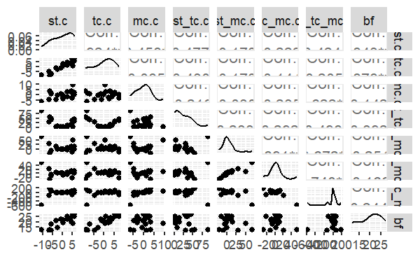

```r
# Looking at the new correlation matrix
GGally::ggpairs(fat.c)
```

Still not perfect, but notice that the correlations have been drastically reduced for some of the interaction variables. Why does this work? Consider two variables that are highly correlated:

[figure not shown]

```r
# Calculate a simple linear regression for each variable (not the interactions).
regression1.out <- lm(bf ~ st.c)
regression2.out <- lm(bf ~ tc.c)
regression3.out <- lm(bf ~ mc.c)
```

```r
summary(regression1.out)
```

```
Call:
lm(formula = bf ~ st.c)

Residuals:
    Min      1Q  Median      3Q     Max
-6.1195 -2.1904  0.6735  1.9383  3.8523

Coefficients:
            Estimate Std. Error t value Pr(>|t|)
(Intercept)  20.1950     0.6305  32.029  < 2e-16 ***
st.c          0.8572     0.1288   6.656 3.02e-06 ***
---
Signif. codes:
0 ‘***’ 0.001 ‘**’ 0.01 ‘*’ 0.05 ‘.’ 0.1 ‘ ’ 1

Residual standard error: 2.82 on 18 degrees of freedom
Multiple R-squared:  0.7111,    Adjusted R-squared:  0.695
F-statistic:  44.3 on 1 and 18 DF,  p-value: 3.024e-06
```

```r
confint.lm(regression1.out,'st.c',level=0.95)
```

```
         2.5 %   97.5 %
st.c 0.5866281 1.127745
```

```r
print("Model2")
```

```
[1] "Model2"
```

```r
summary(regression2.out)
```

```
Call:
lm(formula = bf ~ tc.c)

Residuals:
    Min      1Q  Median      3Q     Max
-4.4949 -1.5671  0.1241  1.3362  4.4084

Coefficients:
            Estimate Std. Error t value Pr(>|t|)
(Intercept)  20.1950     0.5613  35.979  < 2e-16 ***
tc.c          0.8565     0.1100   7.786  3.6e-07 ***
---
Signif. codes:
0 ‘***’ 0.001 ‘**’ 0.01 ‘*’ 0.05 ‘.’ 0.1 ‘ ’ 1

Residual standard error: 2.51 on 18 degrees of freedom
Multiple R-squared:  0.771, Adjusted R-squared:  0.7583
F-statistic: 60.62 on 1 and 18 DF,  p-value: 3.6e-07
```

```r
confint.lm(regression2.out,'tc.c',level=0.95)
```

```
         2.5 %   97.5 %
tc.c 0.6254123 1.087681
```

```r
print("Model3")
```

```
[1] "Model3"
```

```r
summary(regression3.out)
```

```
Call:
lm(formula = bf ~ mc.c)

Residuals:
   Min     1Q Median     3Q    Max
-8.590 -3.847  1.458  3.561  6.909

Coefficients:
            Estimate Std. Error t value Pr(>|t|)
(Intercept)  20.1950     1.1611  17.393 1.06e-12 ***
mc.c          0.1994     0.3266   0.611    0.549
---
Signif. codes:
0 ‘***’ 0.001 ‘**’ 0.01 ‘*’ 0.05 ‘.’ 0.1 ‘ ’ 1

Residual standard error: 5.193 on 18 degrees of freedom
Multiple R-squared:  0.02029,   Adjusted R-squared:  -0.03414
F-statistic: 0.3728 on 1 and 18 DF,  p-value: 0.5491
```

```r
confint.lm(regression3.out,'mc.c',level=0.95)
```

```
         2.5 %    97.5 %
mc.c -0.486795 0.8856523
```

- Two of the three variables seem to have a strong effect,
- but effect of mc.c is inconclusive (NOT NEGATIVE!!)

```r
# Calculate a multiple linear regression for all variables,
# without interactions.
regression4.out <- lm(bf ~ st.c + tc.c + mc.c)
summary(regression4.out)
```

```
Call:
lm(formula = bf ~ st.c + tc.c + mc.c)

Residuals:
    Min      1Q  Median      3Q     Max
-3.7263 -1.6111  0.3923  1.4656  4.1277

Coefficients:
            Estimate Std. Error t value Pr(>|t|)
(Intercept)  20.1950     0.5545  36.418   <2e-16 ***
st.c          4.3341     3.0155   1.437    0.170
tc.c         -2.8568     2.5820  -1.106    0.285
mc.c         -2.1861     1.5955  -1.370    0.190
---
Signif. codes:
0 ‘***’ 0.001 ‘**’ 0.01 ‘*’ 0.05 ‘.’ 0.1 ‘ ’ 1

Residual standard error: 2.48 on 16 degrees of freedom
Multiple R-squared:  0.8014,    Adjusted R-squared:  0.7641
F-statistic: 21.52 on 3 and 16 DF,  p-value: 7.343e-06
```

```r
confint.lm(regression4.out)
```

```
                2.5 %    97.5 %
(Intercept) 19.019426 21.370574
st.c        -2.058507 10.726691
tc.c        -8.330476  2.616780
mc.c        -5.568367  1.196247
```

Compared to the univariate results, we see many changes, because of high confounding between st.c and tc.c. Since they provide such similar information, we will drop tc.c (somewhat arbitrary choice, in general, this choice can be made from substantive theory or preferences).

```r
regression5.out <- lm(bf ~ st.c + mc.c)
summary(regression5.out)
```

```
Call:
lm(formula = bf ~ st.c + mc.c)

Residuals:
    Min      1Q  Median      3Q     Max
-3.8794 -1.9627  0.3811  1.2688  3.8942

Coefficients:
            Estimate Std. Error t value Pr(>|t|)
(Intercept)  20.1950     0.5582  36.180  < 2e-16 ***
st.c          1.0006     0.1282   7.803 5.12e-07 ***
mc.c         -0.4314     0.1766  -2.443   0.0258 *
---
Signif. codes:
0 ‘***’ 0.001 ‘**’ 0.01 ‘*’ 0.05 ‘.’ 0.1 ‘ ’ 1

Residual standard error: 2.496 on 17 degrees of freedom
Multiple R-squared:  0.7862,    Adjusted R-squared:  0.761
F-statistic: 31.25 on 2 and 17 DF,  p-value: 2.022e-06
```

```r
confint.lm(regression5.out)
```

```
                 2.5 %      97.5 %
(Intercept) 19.0173315 21.37266851
st.c         0.7300389  1.27113097
mc.c        -0.8040683 -0.05881575
```

- Much better result, note how much narrower CI’s are, both variables have at least a small effect, likely of clinical interest.

```r
# Add in the interaction between st.c and mc.c
regression6.out <- lm(bf ~ st.c + mc.c + st_mc.c)

summary(regression6.out)
```

```
Call:
lm(formula = bf ~ st.c + mc.c + st_mc.c)

Residuals:
    Min      1Q  Median      3Q     Max
-3.4587 -1.9781  0.1003  1.8861  3.9143

Coefficients:
            Estimate Std. Error t value Pr(>|t|)
(Intercept) 20.37496    0.60663  33.587 2.89e-16 ***
st.c         0.98153    0.13171   7.452 1.37e-06 ***
mc.c        -0.42338    0.17875  -2.369   0.0308 *
st_mc.c     -0.02259    0.02803  -0.806   0.4321
---
Signif. codes:
0 ‘***’ 0.001 ‘**’ 0.01 ‘*’ 0.05 ‘.’ 0.1 ‘ ’ 1

Residual standard error: 2.522 on 16 degrees of freedom
Multiple R-squared:  0.7945,    Adjusted R-squared:  0.756
F-statistic: 20.62 on 3 and 16 DF,  p-value: 9.598e-06
```

```r
confint.lm(regression6.out)
```

```
                 2.5 %      97.5 %
(Intercept) 19.0889616 21.66095234
st.c         0.7023131  1.26075526
mc.c        -0.8023074 -0.04446157
st_mc.c     -0.0820029  0.03682957
```

### Draw overall conclusions based on the totality of evidence from all models.

> There is no strong evidence of an interaction, but can we rule it out?Checking the descriptive statistics of the interaction term st_mc.c, we see that a 1 SD change means a change of

```r
sqrt(var(st_mc.c))
#[1] 20.99732

# Take the coefficient, multiply by this SD, we get:
sqrt(var(st_mc.c)) * -0.02259
#[1] -0.4743296

# Similarly, for upper and lower CI limits:
sqrt(var(st_mc.c)) * c(-0.0820029, 0.03682957)
#[1] -1.7218415 0.7733224
```

| Subject | Skinfold Thickness | Thigh Circumference | Midarm Circumference | Body Fat |
| --- | --- | --- | --- | --- |
| 2 | 24.7 | 49.8 | 28.2 | 22.8 |
| 3 | 30.7 | 51.9 | 37.0 | 18.7 |
| 4 | 29.8 | 54.3 | 31.1 | 20.1 |
| 6 | 25.6 | 53.9 | 23.7 | 21.7 |
| 7 | 31.4 | 58.5 | 27.6 | 27.1 |
| 8 | 27.9 | 52.1 | 30.6 | 25.4 |
| 9 | 22.1 | 49.9 | 23.2 | 21.3 |
| 10 | 25.5 | 53.5 | 24.8 | 19.3 |
| 11 | 31.1 | 56.6 | 30.0 | 25.4 |
| 12 | 30.4 | 56.7 | 28.3 | 27.2 |

[output cut: 5 more lines]